# k-means clustering

clustering -grouping unlabelled data based on their sililarity or prosimity

# importing the libraries

```python
import numpy as np
import matplotlib.pyplot as plt
import pandas as pd
```

# importing the dataset

```python
df = pd.read_csv(r"E:\python class pdf\Data Files used in Projects\Customers_spending.csv")
```

```python
df.head()
```

|  | CustomerID | Genre | Age | Annual Income (k$) | Spending Score (1-100) |
| --- | --- | --- | --- | --- | --- |
| 0 | 1 | Male | 19 | 15 | 39 |
| 1 | 2 | Male | 21 | 15 | 81 |
| 2 | 3 | Female | 20 | 16 | 6 |
| 3 | 4 | Female | 23 | 16 | 77 |
| 4 | 5 | Female | 31 | 17 | 40 |

retreive the values from column 3 and column 4 of the df (all rows ) and return them as a NumPy array

```python
x=df.iloc[:,[3,4]].values
```

```python
x
```

```
array([[ 15,  39],
       [ 15,  81],
       [ 16,   6],
       [ 16,  77],
       [ 17,  40],
       [ 17,  76],
       [ 18,   6],
       [ 18,  94],
       [ 19,   3],
       [ 19,  72],
       [ 19,  14],
       [ 19,  99],
       [ 20,  15],
       [ 20,  77],
       [ 20,  13],
       [ 20,  79],
       [ 21,  35],
       [ 21,  66],
       [ 23,  29],
       [ 23,  98],
       [ 24,  35],
       [ 24,  73],
       [ 25,   5],
       [ 25,  73],
       [ 28,  14],
       [ 28,  82],
       [ 28,  32],
       [ 28,  61],
       [ 29,  31],
       [ 29,  87],
       [ 30,   4],
       [ 30,  73],
       [ 33,   4],
       [ 33,  92],
       [ 33,  14],
       [ 33,  81],
       [ 34,  17],
       [ 34,  73],
       [ 37,  26],
       [ 37,  75],
```

[output cut: 145 more lines]

```
       [ 99,  97],
       [101,  24],
       [101,  68],
       [103,  17],
       [103,  85],
       [103,  23],
       [103,  69],
       [113,   8],
       [113,  91],
       [120,  16],
       [120,  79],
       [126,  28],
       [126,  74],
       [137,  18],
       [137,  83]], dtype=int64)
```

# Using the elbow method to find the optimal number of clusters

The elbow method is a technique used in clustering analysis to determine the optimal number of clusters to use for partitioning a dataset

# WCSS(within-cluster sum of squares)

- the WSCC is the sum of the squared distances between each data point and the centroid of its assigned cluster.
- in general , as you increase the number of clustrs, the WCSS will decrease since data points will be closer to the centroids of their respective clusters.However ,adding too many clusters may lead to overfiting and decrease the interpretability of the results

# inertia

it gives the sum of the squared distance between data points and their assigned cluster centers .this value is added to the WCSS list

# init ='k-means++'

This specifies that the initial cluster cneters should be selected using the k-means++ initialization method

# Elbow Point

- THe "elbow point" on the WCSS plot is the point at which the rate of decrease sharply changes , creating an "elbow" shape.
- this point represents balance between minimisisng WCSS nd avoiding too many clusters.
- the idea is to choose the number of clusters at this elbow point.

[output not shown]

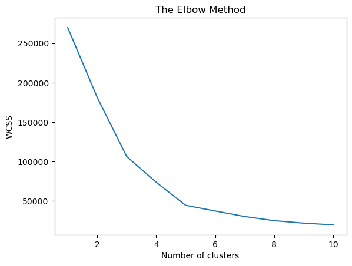

```python
from sklearn.cluster import KMeans
wcss = []
for i in range(1,11):
    kmeans = KMeans(n_clusters = i, init = 'k-means++', random_state = 99)
    kmeans.fit(x)
    wcss.append(kmeans.inertia_)
plt.plot(range(1,11), wcss)
plt.title('The Elbow Method')
plt.xlabel('Number of clusters')
plt.ylabel('WCSS')
plt.show()
```

# Training the K-Means model on the dataset

```python
kmeans = KMeans(n_clusters = 5, init = 'k-means++', random_state = 100)
y_kmeans = kmeans.fit_predict(x)
```

```python
y_kmeans
```

```
array([3, 2, 3, 2, 3, 2, 3, 2, 3, 2, 3, 2, 3, 2, 3, 2, 3, 2, 3, 2, 3, 2,
       3, 2, 3, 2, 3, 2, 3, 2, 3, 2, 3, 2, 3, 2, 3, 2, 3, 2, 3, 2, 3, 0,
       3, 2, 0, 0, 0, 0, 0, 0, 0, 0, 0, 0, 0, 0, 0, 0, 0, 0, 0, 0, 0, 0,
       0, 0, 0, 0, 0, 0, 0, 0, 0, 0, 0, 0, 0, 0, 0, 0, 0, 0, 0, 0, 0, 0,
       0, 0, 0, 0, 0, 0, 0, 0, 0, 0, 0, 0, 0, 0, 0, 0, 0, 0, 0, 0, 0, 0,
       0, 0, 0, 0, 0, 0, 0, 0, 0, 0, 0, 0, 0, 1, 4, 1, 0, 1, 4, 1, 4, 1,
       0, 1, 4, 1, 4, 1, 4, 1, 4, 1, 0, 1, 4, 1, 4, 1, 4, 1, 4, 1, 4, 1,
       4, 1, 4, 1, 4, 1, 4, 1, 4, 1, 4, 1, 4, 1, 4, 1, 4, 1, 4, 1, 4, 1,
       4, 1, 4, 1, 4, 1, 4, 1, 4, 1, 4, 1, 4, 1, 4, 1, 4, 1, 4, 1, 4, 1,
       4, 1])
```

# Visualising the clusters

```python
#plt.scatter(x,y)
#plt.scatter(x[y_kmeans==0,0])
```

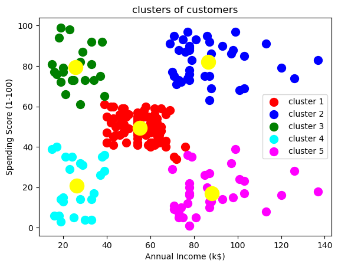

```python
plt.scatter(x[y_kmeans == 0,0], x[y_kmeans == 0,1], s = 100, c='red', label = 'cluster 1')
plt.scatter(x[y_kmeans == 1,0], x[y_kmeans == 1,1], s = 100, c='blue', label = 'cluster 2')
plt.scatter(x[y_kmeans == 2,0], x[y_kmeans == 2,1], s = 100, c='green', label = 'cluster 3')
plt.scatter(x[y_kmeans == 3,0], x[y_kmeans == 3,1], s = 100, c='cyan', label = 'cluster 4')
plt.scatter(x[y_kmeans == 4,0], x[y_kmeans == 4,1], s = 100, c='magenta', label = 'cluster 5')
#kmeans.cliuster_centers_[:, 0]and
#kmeans.cluster_centers_[:, 1]extract the x and y coordinates of the cluster centroids.
plt.scatter(kmeans.cluster_centers_[:, 0], kmeans.cluster_centers_[:, 1], s = 300, c = 'yellow', )
plt.title('clusters of customers')
plt.xlabel('Annual Income (k$)')
plt.ylabel('Spending Score (1-100)')
plt.legend()
plt.show()
```